# RegLab Home Assignment

2023-03-25

## Part I

Loading data + preprocessing. Add the cuisine variable to the dataset (step 2).

```r
setwd("/Users/asya/Dropbox/_ jobs/RegLab")

library(tidyverse)
cuisines_df <- read.csv("cuisines.csv")
food_violations <- read.csv("food_violations_seattle.csv") %>%
  # change strings to the R data type (two variables)
  mutate_at(vars(starts_with('inspection_period_')), ~ as.Date(.x))

nrow(food_violations)
```

```
## [1] 13299
```

```r
### add the cuisine variable

food_violations <- food_violations %>%
  # delete unnecessary symbols
  mutate(cuisines = str_replace_all(cuisines, '\'|\\[|\\]', '') %>%
  # leverage the dplyr functionality to create a list variable:
           str_split(', ')) %>%
  # create the long version of the data:
  unnest(cuisines) %>%
  # match the dataset with the cuisine variable:
  left_join(., cuisines_df %>%
              rename(cuisines = x), by = c('cuisines')) %>%
  # for the rest of the dataset:
  group_by_at(vars(-cuisines, -asian, -ethnic)) %>%
  # convert the dataset back to the wide format,
  # the restaurant is recorded as Asian if at least one attribute of its cuisine var is Asian
  # same for Ethnic
  summarise(cuisines = list(cuisines),
            asian = ifelse(sum(asian) > 0, 1, 0),
            ethnic = ifelse(sum(ethnic) > 0, 1, 0))
```

[output not shown]

```r
nrow(food_violations)
```

```
## [1] 13299
```

Step 1. The spread of violation scores and exploratory data analysis.

Using the method of your choice, analyze the spread of violation scores among restaurants. Feel free to demonstrate any additional exploratory data analysis you feel is helpful for your understanding.

```r
# timeline: reviews from July 2005 to Feb 2013
summary(food_violations$inspection_period_start_date)
```

```
##         Min.      1st Qu.       Median         Mean      3rd Qu.         Max.
## "2005-07-07" "2008-06-04" "2010-03-16" "2009-11-24" "2011-06-23" "2013-01-24"
```

```r
summary(food_violations$inspection_period_end_date)
```

```
##         Min.      1st Qu.       Median         Mean      3rd Qu.         Max.
## "2006-01-03" "2009-01-22" "2010-10-04" "2010-05-31" "2012-02-02" "2013-02-08"
```

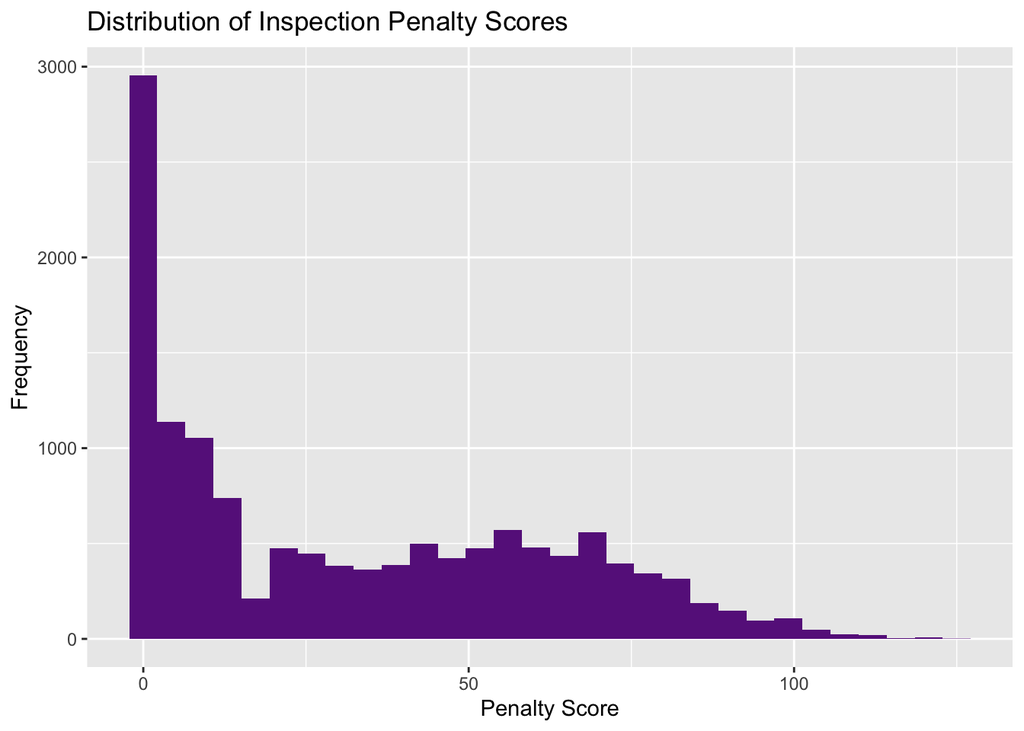

```r
# distribution of inspection_penalty_score
food_violations %>%
  ggplot() +
  geom_histogram(aes(x = inspection_penalty_score), bins = 30, fill = "darkorchid4") +
  labs(title = "Distribution of Inspection Penalty Scores",
       x = "Penalty Score",
       y = "Frequency")
```

A lot of restaurants received a low penalty score, but we still have plenty of observations with high scores. Let’s explore it, especially restaurants with ‘severe’ violation penalty scores (10 and more).

```r
# add a severe violation column
food_violations <- food_violations %>%
  mutate(severe_violation = ifelse(inspection_penalty_score >= 10, 1, 0))

# create a cuisine type dataset for each restaurant
food_violations_by_cuisine <- food_violations %>%
  group_by(restaurant_id) %>% # for each restaurant
  summarise(n_severe_violations = sum(severe_violation),
            # preserve the asian and ethnic columns
            asian = mean(asian),
            ethnic = mean(ethnic)) %>%
  mutate(rest_type = paste0(ifelse(ethnic == 1, 'Ethnic', 'Non-Ethnic'), ', ',
                            ifelse(asian == 1, 'Asian', 'Non-Asian')))

# number of restaurants == 1756:
nrow(food_violations_by_cuisine)
```

```
## [1] 1756
```

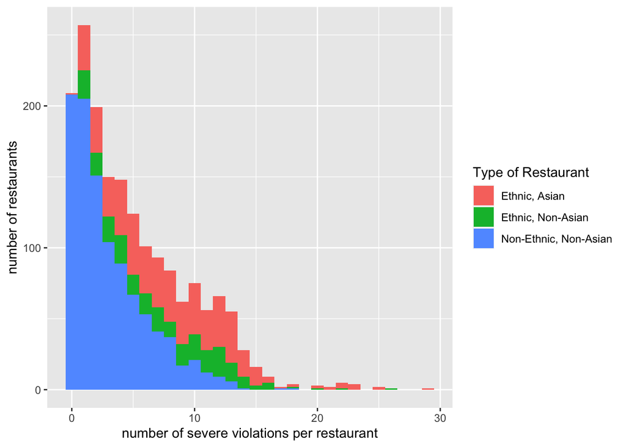

```r
# visualize the number of restaurants by severe violations and ethnic / asian group
food_violations_by_cuisine %>%
  ggplot() +
  geom_histogram(aes(x = n_severe_violations, fill = rest_type),
                 bins = 30, position = "stack") +
  labs(y = "number of restaurants",
       x = "number of severe violations per restaurant",
       fill = "Type of Restaurant")
```

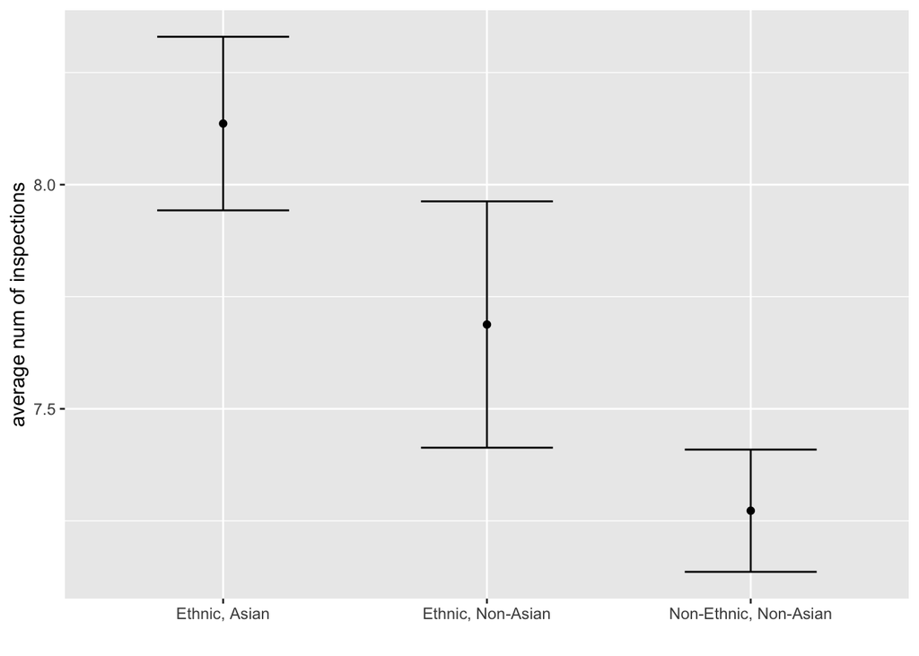

```r
food_violations %>%
  group_by(restaurant_id) %>% # for each restaurant
  summarise(n_inspections = n(),
            # preserve the asian and ethnic columns
            asian = mean(asian),
            ethnic = mean(ethnic)) %>%
  mutate(rest_type = paste0(ifelse(ethnic == 1, 'Ethnic', 'Non-Ethnic'), ', ',
                            ifelse(asian == 1, 'Asian', 'Non-Asian'))) %>%
  group_by(rest_type) %>%
  summarise(mean_n_inspections = mean(n_inspections),
           sd_ = sd(n_inspections),
           n_ = n()
            ) %>%
  mutate( CI_n_inspections_l= mean_n_inspections - qnorm(0.975)*sqrt(sd_/n_),
            CI_n_inspections_u = mean_n_inspections + qnorm(0.975)*sqrt(sd_/n_)) %>%
  select(-sd_, -n_) %>%
  #pivot_longer(., cols = c(-rest_type)) %>%
  ggplot() +
  geom_point(aes(x = rest_type, y = mean_n_inspections)) +
  geom_errorbar(aes(x = rest_type, ymax = CI_n_inspections_u,
                    ymin = CI_n_inspections_l), width = .5) +
  labs(x = " ", y = "average num of inspections")
```

We can also explore the link between reviews and violations for restaurants.

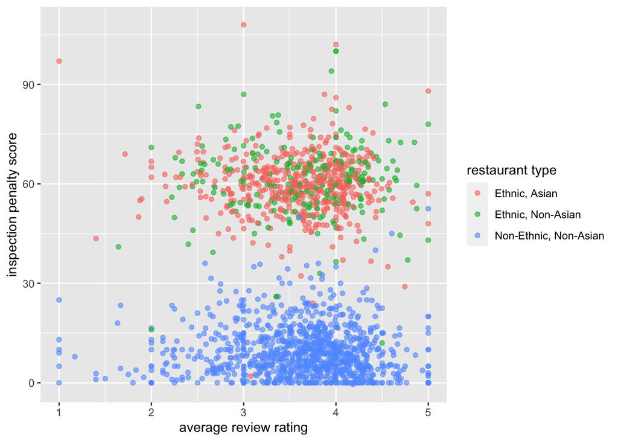

```r
food_violations %>%
  group_by(restaurant_id) %>%  # for each restaurant
  summarise(average_review_rating = mean(average_review_rating),  # preserve the score
            # mean inspection score per restaurant
            inspection_penalty_score = mean(inspection_penalty_score),
            # preserve the asian and ethnic columns
            asian = mean(asian),
            ethnic = mean(ethnic)) %>%
  mutate(rest_type = paste0(ifelse(ethnic == 1, 'Ethnic', 'Non-Ethnic'), ', ',
                            ifelse(asian == 1, 'Asian', 'Non-Asian'))) %>%
    ggplot() +
    geom_point(aes(x = average_review_rating,
                   y = inspection_penalty_score,
                   color = rest_type),
               alpha = .6) +
  labs(x = "average review rating",
       y = "inspection penalty score",
       color = "restaurant type")
```

We can see that the inspection decision is biased. The distribution of review ratings is similar-ish across cuisine groups with an average approximately slightly less than 4.

What about the relationship between previous and current penalty scores? Is it different across different cuisine groups? The more frequent inspections of ethnic restaurants that we observed may drive ethnic restaurants to enhance their performance and get better inspection scores under such scrutiny and out of concern for potential closure.

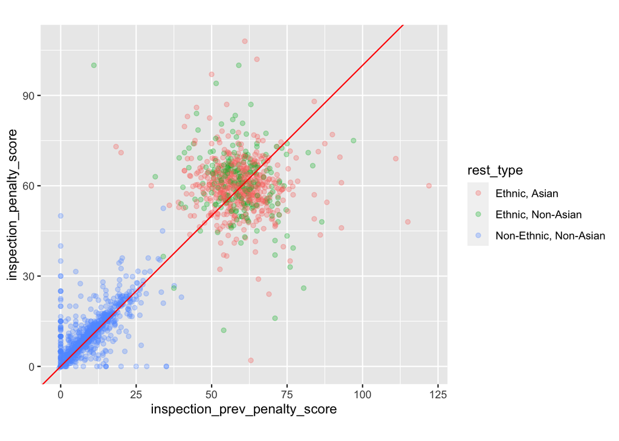

```r
food_violations %>%
  group_by(restaurant_id) %>%
  # get mean penalty scores (most recent and previous) for each restaurant
  summarise(inspection_prev_penalty_score = mean(inspection_prev_penalty_score),
            inspection_penalty_score = mean(inspection_penalty_score),
            asian = mean(asian),
            ethnic = mean(ethnic))  %>%
  mutate(rest_type = paste0(ifelse(ethnic == 1, 'Ethnic', 'Non-Ethnic'), ', ',
                            ifelse(asian == 1, 'Asian', 'Non-Asian'))) %>%
  ggplot() +
  geom_point(aes(y = inspection_penalty_score,
      x = inspection_prev_penalty_score, color = rest_type), alpha = 0.3) +
  geom_abline(intercept = 0, slope = 1, color = 'red') +
  coord_equal()
```

Now, let’s think of the same problem form the perspective of scores improvement. Does the penalty improvement score distribution look different across cuisine groups?

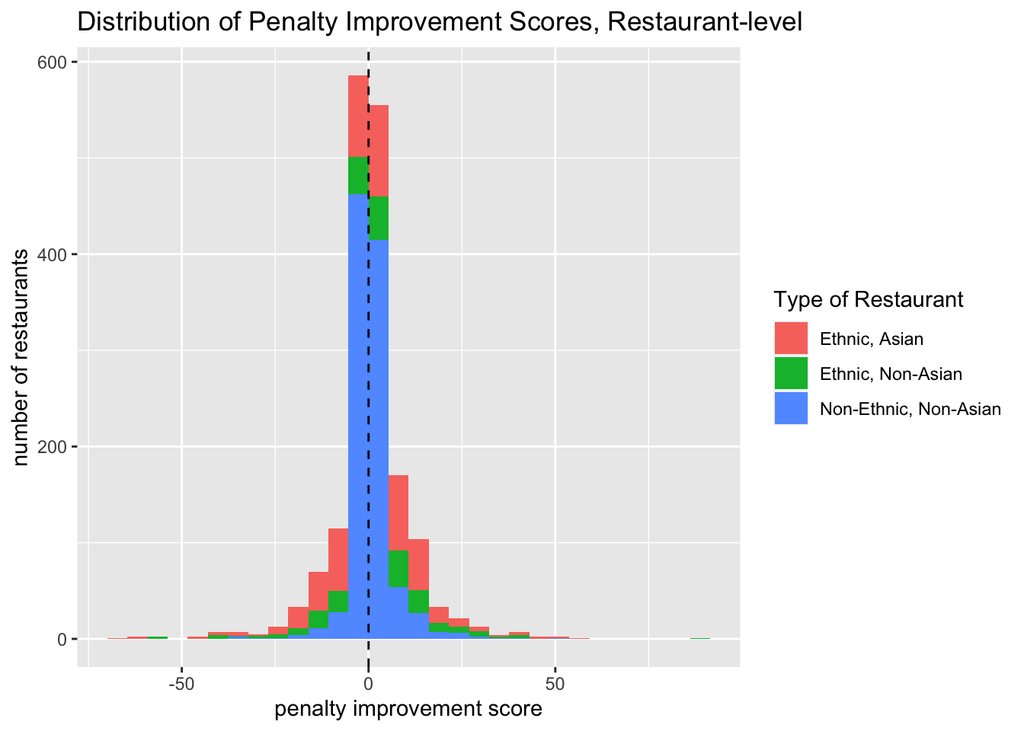

```r
food_violations %>%
  mutate( # create a penalty improvement variable
    after_penalty_improvement = inspection_penalty_score - inspection_prev_penalty_score
  ) %>%
  group_by(restaurant_id) %>%
  # preserve the three variables by calculating its means for each restaurant
  summarise_at(vars(after_penalty_improvement, asian, ethnic), mean) %>%
  mutate(rest_type = paste0(ifelse(ethnic == 1, 'Ethnic', 'Non-Ethnic'), ', ',
                            ifelse(asian == 1, 'Asian', 'Non-Asian'))) %>%
  ggplot() +
  # dist of penalty improvement for each rest type
  geom_histogram(aes(x = after_penalty_improvement, fill = rest_type),
                 bins = 30, position = "stack", boundary=0) +
  geom_vline(xintercept = 0,
             linetype = 2) +
  labs(y = "number of restaurants",
       x = "penalty improvement score",
       fill = "Type of Restaurant",
       title = "Distribution of Penalty Improvement Scores, Restaurant-level")
```

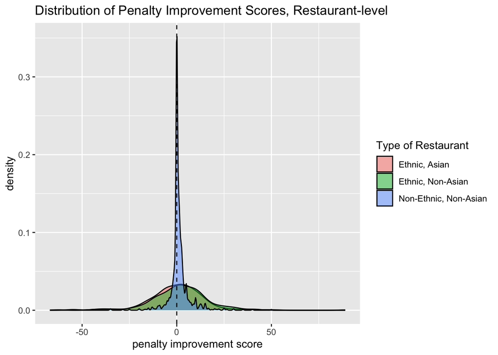

```r
food_violations %>%
  mutate( # create a penalty improvement variable
    after_penalty_improvement = inspection_penalty_score - inspection_prev_penalty_score
  ) %>%
  group_by(restaurant_id) %>%
  # preserve the three variables by calculating its means for each restaurant
  summarise_at(vars(after_penalty_improvement, asian, ethnic), mean) %>%
  mutate(rest_type = paste0(ifelse(ethnic == 1, 'Ethnic', 'Non-Ethnic'), ', ',
                            ifelse(asian == 1, 'Asian', 'Non-Asian'))) %>%
  ggplot() +
  # density plot of penalty improvement for each rest type
  geom_density(aes(x = after_penalty_improvement, fill = rest_type), alpha = 0.5) +
  geom_vline(xintercept = 0, linetype = 2) +
  labs(y = "density",
       x = "penalty improvement score",
       fill = "Type of Restaurant",
       title = "Distribution of Penalty Improvement Scores, Restaurant-level")
```

The density graph clearly show that the improvement score for non-ethnic restaurants hovers around zero. One possible explanation is that these restaurants lack incentives to get better inspection scores (they’re not inspected that often and get better scores on average in comparison to ethnic restaurants).

We can also inspect the relationship between penalty previous and current scores within cuisine groups by estimating a bunch of simple linear models with interaction terms.

```r
# + commit changes to the dataset (save the 'rest_type' var I've been using frequently)
food_violations <- food_violations %>%
  mutate(cuisine_type_joint = paste0(ifelse(ethnic == 1, 'Ethnic', 'Non-Ethnic'), ', ',
                            ifelse(asian == 1, 'Asian', 'Non-Asian')))

# i.e. add the rest_type (cuisine type) var into the dataset
food_violations <- food_violations %>%
  mutate(cuisine_type_joint = factor(cuisine_type_joint))

######
m1 <- lm(inspection_penalty_score ~ inspection_prev_penalty_score, data = food_violations)
m2 <- lm(inspection_penalty_score ~ inspection_prev_penalty_score * cuisine_type_joint, data = food_violations)


summary(food_violations$inspection_penalty_score)
```

```
##    Min. 1st Qu.  Median    Mean 3rd Qu.    Max.
##   -1.00    5.00   25.00   32.08   57.00  124.00
```

```r
summary(food_violations$inspection_prev_penalty_score)
```

```
##    Min. 1st Qu.  Median    Mean 3rd Qu.    Max.
##   -1.00    3.00   24.00   31.36   56.00  143.00
```

```r
summary(m1)
```

```
##
## Call:
## lm(formula = inspection_penalty_score ~ inspection_prev_penalty_score,
##     data = food_violations)
##
## Residuals:
##     Min      1Q  Median      3Q     Max
## -94.874 -11.279  -4.862  11.465  94.138
##
## Coefficients:
##                               Estimate Std. Error t value Pr(>|t|)
## (Intercept)                   9.862028   0.265306   37.17   <2e-16 ***
## inspection_prev_penalty_score 0.708430   0.006141  115.36   <2e-16 ***
## ---
## Signif. codes:  0 '***' 0.001 '**' 0.01 '*' 0.05 '.' 0.1 ' ' 1
##
## Residual standard error: 21.05 on 13297 degrees of freedom
## Multiple R-squared:  0.5002, Adjusted R-squared:  0.5002
## F-statistic: 1.331e+04 on 1 and 13297 DF,  p-value: < 2.2e-16
```

```r
summary(m2)
```

```
##
## Call:
## lm(formula = inspection_penalty_score ~ inspection_prev_penalty_score *
##     cuisine_type_joint, data = food_violations)
##
## Residuals:
##     Min      1Q  Median      3Q     Max
## -62.605  -8.430  -3.011   8.882  95.989
##
## Coefficients:
##                                                                        Estimate
## (Intercept)                                                            60.98525
## inspection_prev_penalty_score                                          -0.02064
## cuisine_type_jointNon-Ethnic, Non-Asian                               -52.97434
## cuisine_type_jointEthnic, Non-Asian                                     2.23690
## inspection_prev_penalty_score:cuisine_type_jointNon-Ethnic, Non-Asian   0.22998
## inspection_prev_penalty_score:cuisine_type_jointEthnic, Non-Asian      -0.02051
##                                                                       Std. Error
## (Intercept)                                                              0.78136
## inspection_prev_penalty_score                                            0.01249
## cuisine_type_jointNon-Ethnic, Non-Asian                                  0.81494
## cuisine_type_jointEthnic, Non-Asian                                      1.42166
## inspection_prev_penalty_score:cuisine_type_jointNon-Ethnic, Non-Asian    0.01880
## inspection_prev_penalty_score:cuisine_type_jointEthnic, Non-Asian        0.02286
##                                                                       t value
## (Intercept)                                                            78.050
## inspection_prev_penalty_score                                          -1.652
## cuisine_type_jointNon-Ethnic, Non-Asian                               -65.004
## cuisine_type_jointEthnic, Non-Asian                                     1.573
## inspection_prev_penalty_score:cuisine_type_jointNon-Ethnic, Non-Asian  12.236
## inspection_prev_penalty_score:cuisine_type_jointEthnic, Non-Asian      -0.897
##                                                                       Pr(>|t|)
## (Intercept)                                                             <2e-16
## inspection_prev_penalty_score                                           0.0985
## cuisine_type_jointNon-Ethnic, Non-Asian                                 <2e-16
## cuisine_type_jointEthnic, Non-Asian                                     0.1156
## inspection_prev_penalty_score:cuisine_type_jointNon-Ethnic, Non-Asian   <2e-16
## inspection_prev_penalty_score:cuisine_type_jointEthnic, Non-Asian       0.3697
##
## (Intercept)                                                           ***
## inspection_prev_penalty_score                                         .
## cuisine_type_jointNon-Ethnic, Non-Asian                               ***
## cuisine_type_jointEthnic, Non-Asian
## inspection_prev_penalty_score:cuisine_type_jointNon-Ethnic, Non-Asian ***
## inspection_prev_penalty_score:cuisine_type_jointEthnic, Non-Asian
## ---
## Signif. codes:  0 '***' 0.001 '**' 0.01 '*' 0.05 '.' 0.1 ' ' 1
##
## Residual standard error: 16.24 on 13293 degrees of freedom
## Multiple R-squared:  0.7024, Adjusted R-squared:  0.7023
## F-statistic:  6275 on 5 and 13293 DF,  p-value: < 2.2e-16
```

The model with the interaction term indicates that the pooled effect of previous penalty score on current penalty score is weak and not significant – the first model thus captures the significant relationship between previous and current penalty scores for a specific cuisine group. We also should note that non-ethic non-asian restaurants have a statistically significantly lower intercept, compared to the reference level (Ethnic, Asian), i.e. the predicted mean penalty score is 53 higher for Asian restaurants than non-ethnic restaurants. Meanwhile, the intercept difference between within ethnic restaurants is not statistically significant.

The effect of previous penalty score on current penalty score is statistically different between non-ethnic and Asian restaurants, whereas there is no statistical difference between previous and current penalty scores withing the ethnic cuisine group.

Let’s change the reference level to `Non-Ethnic, Non-Asian` to compare Ethnic restaurant with non-Ethnic.

```r
# create contrast matrix
contrasts(food_violations$cuisine_type_joint) <-
  contr.treatment(3, base = 3)

# non-ethnic as the reference group
m3 <- lm(inspection_penalty_score ~ inspection_prev_penalty_score * relevel(cuisine_type_joint, ref = 2),
                  data = food_violations)

summary(m3)
```

```
##
## Call:
## lm(formula = inspection_penalty_score ~ inspection_prev_penalty_score *
##     relevel(cuisine_type_joint, ref = 2), data = food_violations)
##
## Residuals:
##     Min      1Q  Median      3Q     Max
## -62.605  -8.430  -3.011   8.882  95.989
##
## Coefficients:
##                                                                                     Estimate
## (Intercept)                                                                          8.01091
## inspection_prev_penalty_score                                                        0.20934
## relevel(cuisine_type_joint, ref = 2)Ethnic, Asian                                   52.97434
## relevel(cuisine_type_joint, ref = 2)Ethnic, Non-Asian                               55.21124
## inspection_prev_penalty_score:relevel(cuisine_type_joint, ref = 2)Ethnic, Asian     -0.22998
## inspection_prev_penalty_score:relevel(cuisine_type_joint, ref = 2)Ethnic, Non-Asian -0.25049
##                                                                                     Std. Error
## (Intercept)                                                                            0.23154
## inspection_prev_penalty_score                                                          0.01404
## relevel(cuisine_type_joint, ref = 2)Ethnic, Asian                                      0.81494
## relevel(cuisine_type_joint, ref = 2)Ethnic, Non-Asian                                  1.21005
## inspection_prev_penalty_score:relevel(cuisine_type_joint, ref = 2)Ethnic, Asian        0.01880
## inspection_prev_penalty_score:relevel(cuisine_type_joint, ref = 2)Ethnic, Non-Asian    0.02374
##                                                                                     t value
## (Intercept)                                                                           34.60
## inspection_prev_penalty_score                                                         14.91
## relevel(cuisine_type_joint, ref = 2)Ethnic, Asian                                     65.00
## relevel(cuisine_type_joint, ref = 2)Ethnic, Non-Asian                                 45.63
## inspection_prev_penalty_score:relevel(cuisine_type_joint, ref = 2)Ethnic, Asian      -12.24
## inspection_prev_penalty_score:relevel(cuisine_type_joint, ref = 2)Ethnic, Non-Asian  -10.55
##                                                                                     Pr(>|t|)
## (Intercept)                                                                           <2e-16
## inspection_prev_penalty_score                                                         <2e-16
## relevel(cuisine_type_joint, ref = 2)Ethnic, Asian                                     <2e-16
## relevel(cuisine_type_joint, ref = 2)Ethnic, Non-Asian                                 <2e-16
## inspection_prev_penalty_score:relevel(cuisine_type_joint, ref = 2)Ethnic, Asian       <2e-16
## inspection_prev_penalty_score:relevel(cuisine_type_joint, ref = 2)Ethnic, Non-Asian   <2e-16
##
## (Intercept)                                                                         ***
## inspection_prev_penalty_score                                                       ***
## relevel(cuisine_type_joint, ref = 2)Ethnic, Asian                                   ***
## relevel(cuisine_type_joint, ref = 2)Ethnic, Non-Asian                               ***
## inspection_prev_penalty_score:relevel(cuisine_type_joint, ref = 2)Ethnic, Asian     ***
## inspection_prev_penalty_score:relevel(cuisine_type_joint, ref = 2)Ethnic, Non-Asian ***
## ---
## Signif. codes:  0 '***' 0.001 '**' 0.01 '*' 0.05 '.' 0.1 ' ' 1
##
## Residual standard error: 16.24 on 13293 degrees of freedom
## Multiple R-squared:  0.7024, Adjusted R-squared:  0.7023
## F-statistic:  6275 on 5 and 13293 DF,  p-value: < 2.2e-16
```

We see that both types of ethnic restaurants have a statistically different relationship between prior and current penalty scores in comparison to non-ethnic restaurants. The effects of previous penalty scores on current ones are expected to be about 0.23-0.25 lower for ethnic restaurants compared to non-ethnic, however, given the domain of the penalty score variable (from -1 to 124), the magnitude of the effect is too low, hence we might’ve observed spurious correlation.

Do restaurants with higher reviews have less incentives to strike for higher inspection scores? Maybe better reviews disincentivize restaurants from trying to score better?

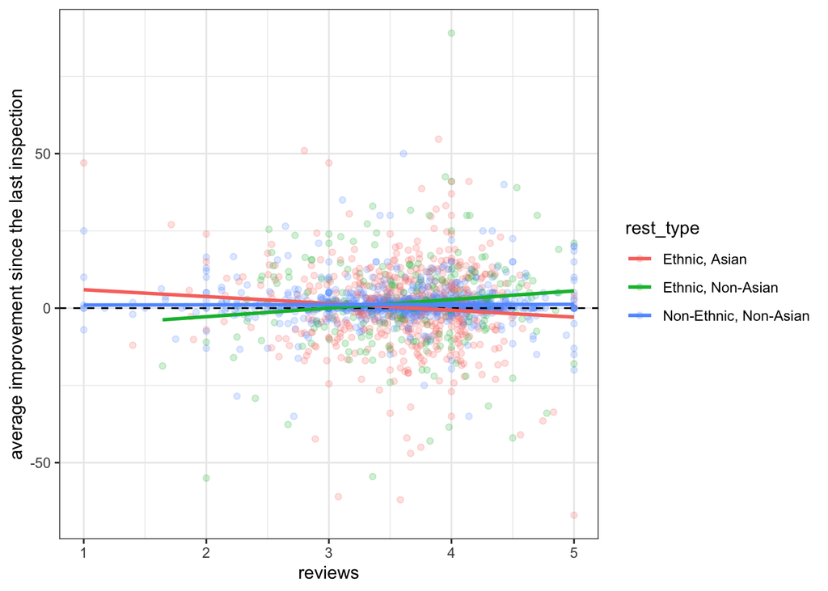

```r
food_violations %>%
  mutate(
    after_penalty_improvement = inspection_penalty_score - inspection_prev_penalty_score
  ) %>%
  group_by(restaurant_id) %>%
  summarise_at(vars(after_penalty_improvement, asian, ethnic, average_review_rating), mean) %>%
  mutate(rest_type = paste0(ifelse(ethnic == 1, 'Ethnic', 'Non-Ethnic'), ', ',
                            ifelse(asian == 1, 'Asian', 'Non-Asian'))) %>%
  #mutate(after_penalty_improvement = sign(after_penalty_improvement) *
  #         log(abs(after_penalty_improvement))) %>%
  ggplot() +
  geom_point(aes(x = average_review_rating, y = after_penalty_improvement, color = rest_type),
             alpha = 0.2) +
  geom_hline(yintercept = 0, linetype = 2) +
  geom_smooth(aes(x = average_review_rating, y= after_penalty_improvement, group = rest_type,
                  color = rest_type),
              method = 'lm', se = F) +
  labs(y = "average improvement since the last inspection",
       x = "reviews",
       fill = "Type of Restaurant") + theme_bw()
```

No such correlation for non-ethnic restaurants, but there is some minor correlation between reviews and improvement scores for ethnic restaurants.

## Part II

Split the dataset into train and test subsets. Unit of analysis = inspection.

```r
set.seed(123)

# use 70% of dataset (randomly) as training set and 30% as test set

train_ids <- sample(1:nrow(food_violations), ceiling(0.7*nrow(food_violations)))
test_ids <- setdiff(1:nrow(food_violations), train_ids)

train_df <- food_violations[train_ids,]
test_df <- food_violations[test_ids,]
```

We’re building a predictive model with a binary outcome = logit with the cuisine type as the main independent variable sounds like the baseline scenario.

To improve the model, we could consider adding additional features such as average review rating, past violation history. We could also collect more data on factors that may affect food safety, such as employee training and food sourcing practices.

We can also add naive controls later on, besides the existing data, if we cluster the analysis by precincts. We can take controls like demographic variables or distance to precincts, or precinct fixed effects. Clustering the analysis by precincts can also help to control for unobserved heterogeneity across different precincts that may influence the likelihood of serious violations.

Moreover, regularization can further improve the predictive power of the model by reducing overfitting and improving generalization performance.

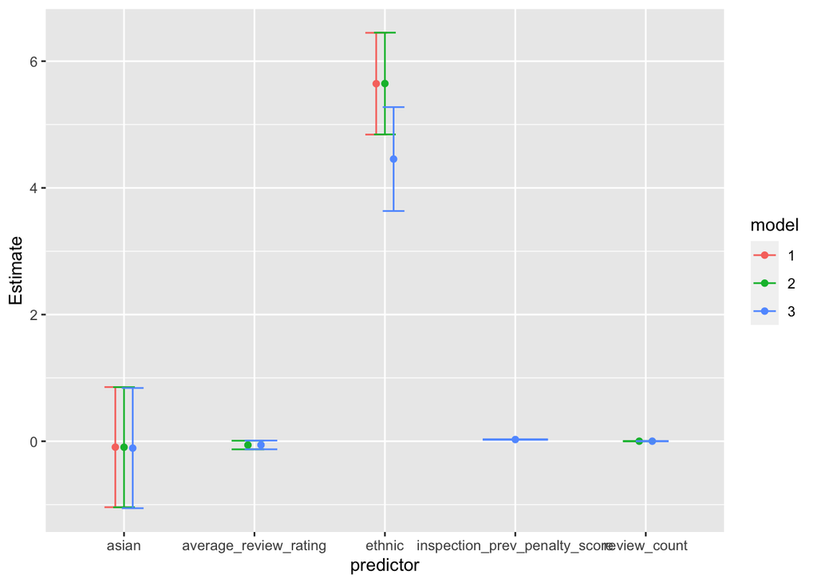

```r
logit0 <- glm(severe_violation ~ asian + ethnic,
              data = train_df, family = binomial(link = "logit"))

# add review ratings and num of reviews aka likability and popularity
logit1 <- glm(severe_violation ~ asian + ethnic + average_review_rating + review_count,
              data = train_df, family = binomial(link = "logit"))

# add previous penalty scores
logit2 <- glm(severe_violation ~ asian + ethnic + average_review_rating + review_count
              + inspection_prev_penalty_score,
              data = train_df, family = binomial(link = "logit"))

test_summaries <- lapply(1:3, function(x)
  summary(list(logit0, logit1, logit2)[[x]])$coefficients[,1:2] %>%
    data.frame() %>%
    mutate(
      predictor = c('Intercept', 'asian', 'ethnic', 'average_review_rating', 'review_count',
  'inspection_prev_penalty_score')[row_number()],
  model = paste0(x)
    )
  )

do.call(rbind, test_summaries) %>%
  filter(predictor != 'Intercept') %>%
  mutate(
    CIl = Estimate - qnorm(0.975)*`Std..Error`,
    CIu = Estimate + qnorm(0.975)*`Std..Error`
  ) %>%
  ggplot() +
  geom_point(aes(x = predictor, y = Estimate, color = model),
             position=position_dodge(width=0.2)) +
  geom_errorbar(aes(x = predictor, ymax = CIu,
                    ymin = CIl,
                    group = model, color = model), width = .5,
                position=position_dodge(width=0.2))
```

```r
test_predictions <-
  lapply(list(logit0, logit1, logit2), function(x)
    predict(x, newdata = test_df, type = 'response'))

predicted_df <-
  do.call(cbind, test_predictions) %>%
  data.frame() %>%
  mutate(
    X1_pred = 1*(X1 > 0.5),
    X2_pred = 1*(X2 > 0.5),
    X3_pred = 1*(X3 > 0.5),
    true_y = test_df$severe_violation
  )

predicted_df %>%
  select(X1_pred, X2_pred, X3_pred, true_y) %>%
  pivot_longer(cols = c(-true_y)) %>%
  mutate(check = 1*(true_y == value)) %>%
  group_by(name) %>%
  summarise(accuracy = mean(check))
```

```
## # A tibble: 3 × 2
##   name    accuracy
##   <chr>      <dbl>
## 1 X1_pred    0.763
## 2 X2_pred    0.763
## 3 X3_pred    0.779
```